# Guest Stars in The Office

## 1. Welcome!

[figure not shown]

.

**The Office!** What started as a British mockumentary series about office culture in 2001 has since spawned ten other variants across the world, including an Israeli version (2010-13), a Hindi version (2019-), and even a French Canadian variant (2006-2007). Of all these iterations (including the original), the American series has been the longest-running, spanning 201 episodes over nine seasons.

In this notebook, we will take a look at a dataset of The Office episodes, and try to understand how the popularity and quality of the series varied over time. To do so, we will use the following dataset: `datasets/office_episodes.csv`, which was downloaded from Kaggle [here](https://www.kaggle.com/nehaprabhavalkar/the-office-dataset).

This dataset contains information on a variety of characteristics of each episode. In detail, these are:

**datasets/office_episodes.csv**

- **episode_number:** Canonical episode number.
- **season:** Season in which the episode appeared.
- **episode_title:** Title of the episode.
- **description:** Description of the episode.
- **ratings:** Average IMDB rating.
- **votes:** Number of votes.
- **viewership_mil:** Number of US viewers in millions.
- **duration:** Duration in number of minutes.
- **release_date:** Airdate.
- **guest_stars:** Guest stars in the episode (if any).
- **director:** Director of the episode.
- **writers:** Writers of the episode.
- **has_guests:** True/False column for whether the episode contained guest stars.
- **scaled_ratings:** The ratings scaled from 0 (worst-reviewed) to 1 (best-reviewed).

```python
# Importing the pandas library
import pandas as pd

# Importing the dataset
df = pd.read_csv('datasets/office_episodes.csv')

#display the first five rows of the DataFrame
display(df.head())
```

|  | episode_number | season | episode_title | description | ratings | votes | viewership_mil | duration | release_date | guest_stars | director | writers | has_guests | scaled_ratings |
| --- | --- | --- | --- | --- | --- | --- | --- | --- | --- | --- | --- | --- | --- | --- |
| 0 | 0 | 1 | Pilot | The premiere episode introduces the boss and s... | 7.5 | 4936 | 11.2 | 23 | 2005-03-24 | NaN | Ken Kwapis | Ricky Gervais \|Stephen Merchant and Greg Daniels | False | 0.28125 |
| 1 | 1 | 1 | Diversity Day | Michael's off color remark puts a sensitivity ... | 8.3 | 4801 | 6.0 | 23 | 2005-03-29 | NaN | Ken Kwapis | B. J. Novak | False | 0.53125 |
| 2 | 2 | 1 | Health Care | Michael leaves Dwight in charge of picking the... | 7.8 | 4024 | 5.8 | 22 | 2005-04-05 | NaN | Ken Whittingham | Paul Lieberstein | False | 0.37500 |
| 3 | 3 | 1 | The Alliance | Just for a laugh, Jim agrees to an alliance wi... | 8.1 | 3915 | 5.4 | 23 | 2005-04-12 | NaN | Bryan Gordon | Michael Schur | False | 0.46875 |
| 4 | 4 | 1 | Basketball | Michael and his staff challenge the warehouse ... | 8.4 | 4294 | 5.0 | 23 | 2005-04-19 | NaN | Greg Daniels | Greg Daniels | False | 0.56250 |

```python
#Creating a list of colors that shows different colors based on the scaled ratings
color = []
for index, rat in df.iterrows():
    if rat['scaled_ratings'] < 0.25:
        color.append("red")
    elif rat['scaled_ratings'] >= 0.25 and rat['scaled_ratings'] < 0.50:
        color.append("orange")
    elif rat['scaled_ratings'] >= 0.50 and rat['scaled_ratings'] < 0.75:
        color.append("lightgreen")
    else:
        color.append("darkgreen")

# Creating a list showing the episode sizes that are the largest with a guest appearance
sizes = []
for index, siz in df.iterrows():
    if siz['has_guests'] == True:
        sizes.append(250)
    else:
        sizes.append(25)
```

```python
print(color)
```

```
['orange', 'lightgreen', 'orange', 'orange', 'lightgreen', 'orange', 'lightgreen', 'orange', 'lightgreen', 'lightgreen', 'orange', 'orange', 'lightgreen', 'orange', 'lightgreen', 'lightgreen', 'lightgreen', 'darkgreen', 'lightgreen', 'orange', 'orange', 'lightgreen', 'lightgreen', 'lightgreen', 'ora…
```

```python
print(sizes)
```

```
[25, 25, 25, 25, 25, 250, 25, 25, 250, 250, 25, 25, 250, 25, 250, 25, 250, 25, 25, 25, 25, 250, 25, 25, 25, 25, 25, 25, 25, 250, 25, 25, 25, 25, 25, 25, 25, 25, 25, 25, 25, 25, 25, 25, 25, 25, 25, 25, 25, 25, 25, 25, 25, 250, 25, 25, 25, 25, 25, 25, 25, 25, 25, 25, 25, 25, 250, 25, 25, 25, 25, 25, 2…
```

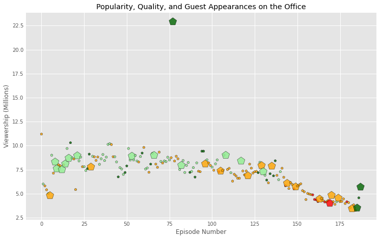

```python
# Import matplotlib.pyplot under its usual alias and create a figure
import matplotlib.pyplot as plt

fig = plt.figure()

# Set figures to be large
plt.rcParams['figure.figsize'] = [11, 7]

# Creating a scatter plot of The Office episodes, that show the popularity and quality of the series varied over time
plt.scatter(df['episode_number'], df['viewership_mil'], c=color, s=sizes, marker="p",alpha=0.8, edgecolor='black', linewidth=0.5)

# Create a title
plt.title("Popularity, Quality, and Guest Appearances on the Office")


# setting label of x-axis and y-axis
plt.xlabel("Episode Number")
plt.ylabel("Viewership (Millions)")

# Show the plot
plt.style.use('ggplot')
plt.show()
```

```python
#showing the name of the guest stars that were in the most-watched Office episode
df.nlargest(1, 'viewership_mil')['guest_stars']
```

```
77    Cloris Leachman, Jack Black, Jessica Alba
Name: guest_stars, dtype: object
```